# CRIM 100 - Introduction and overview

Carlos Ponce

# Sorry!!!

## He’s not coming

[figure not shown]

## We share the same cool accent

[figure not shown]

# Who am I?

## El Salvador

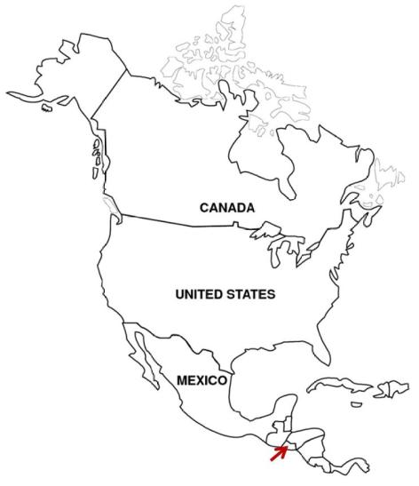

## Economics & business

[figure not shown]

## MA in Criminology

[figure not shown]

## Crime analyst for the Police

[figure not shown]

## Crime analyst for the AG

[figure not shown]

## PhD at SFU

[figure not shown]

## Just started at UFV

[figure not shown]

# Who are you?

## Interview a classmate

- Grab pen and paper
- Find somebody in the class you don’t know well
- Ask the following questions:
  1. What is your name?
  2. Where are you from?
  3. What year are you?
  4. What is your major?
- Report back

# What is this course about?

## Intro to common

- Terms
- Concepts
- Theories
- Findings

## Evaluation

- Midterm exam 30%
- Final exam 30%
- Attendance & participation 10%
- Written assignment 30%

## Readings (week 1-7)

The basics

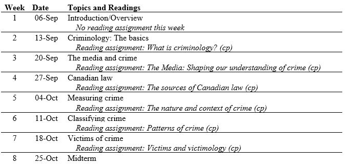

## Readings (week 9-13)

Topic-specific findings

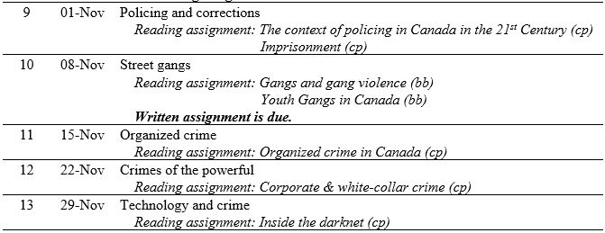

## Written assignment

- Op-ed article (650-750 words)
- Real-life, crime-related issue
- Develop a stance based on course content & academic research articles
- Showcase your grasp of the course material and selected literature
- Frame + explain academic concepts and scientific findings in a simple, clear and concise way
- More instructions to come

# Course policies

## Extensions, Absences, Make-up Assignments and Examinations

- Equitable and fair conditions for all students
- Allow those affected by exceptional & unanticipated circumstances to avoid being negatively impacted
- Exceptional & unaticipated circumstances ARE beyond anyone’s control & signficantly affect the student’s capability to comply with course schedule
- Too many assignments, a wedding, a cold, for example, are NOT exceptional or unanticipated

## What to do if you find yourself in an exceptional & unanticipated circumstance?

- Contact me as soon as possible to inform me about the issue
- Gather and provide adequate documentation that unequivocally demonstrates
  1. the existence of the situation
  2. that the situation is BOTH “unanticipated” and “exceptional”
- Verification and assessment the submitted documents
- If extension/excuse in warranted you have a week to take test or hand in assignment

## Office Hours and Email Correspondence

- I prefer office hours
- Friday’s by appointment
- Allow 48 hours for response
- Email will not be checked on evenings or weekends

## How can you increase the chances of getting a response?

- First read through course materials to make sure your question is not already answered there.
- Sign with your full name and student number.
- Include CRIM 100 in the subject line so that your email is not filtered to the spam folder.
- Use your official UFV email account so we can be certain of your identity.
- Address the recipient formally and professionally, using a respectful, polite, and courteous tone.
- Understand that text messages and emails are two very different things and adjust your expectations accordingly.
- Realize that any time sensitive inquiry that results from poor planning on your part may be an emergency to you but not for us.

## Attendance & Participation

- Students who show up late, depart early, or who engage in otherwise disruptive or non-scholarly behaviour will not be awarded attendance points
- Frequency AND quality of participation will be graded
- In-class exercises
- Use of mobile phones or tablets unless otherwise instructed will result in 0 particpation marks

## School’s Statement on Academic Dishonesty

- The School of Criminology and Criminal Justice takes academic misconduct seriously. We expect students to demonstrate integrity and professionalism. These characteristics are vital to successful careers in the criminal justice system.
- All suspected cases of academic misconduct, such as, but not limited to plagiarism, purchasing papers, re-submitting assignments, and cheating, will be referred to the School’s Director for investigation.

## School’s Statement on Academic Dishonesty (cont.)

- All students who are caught committing academic misconduct will have their name placed on the Academic Misconduct Registry.
- Penalties may include but are not limited to a zero on the assignment, an F in the course, or removal from the program.
- UFV’s Policy 70 provides the full definition, process of investigation, and penalties for academic misconduct.

## Bonus points, extra assignments and grade appeals

- Students will NOT be awarded any kind of bonus points or given extra assignments to increase their score
- Please do not contact me for this
- Contact the School of Criminology for grade appeals
  1. Be advised that grade might go down
  2. Your grade will be changed based on the new score

## Recording, Sharing and Selling Lectures, Lecture Notes and Course Material

- You are not authorized to record or otherwise capture audio, video or still images of lectures, tutorials and/or lecture slides.
- I do not grant students permission to post or sell notes or any other material recorded in lectures by means of audio, video or photographs.
- UFV students, faculty and staff are required to abide by Canada’s Copyright Act as well as UFV’s copyright policies.
- Any violations will be dealt with accordingly.

## Student are expected to:

- Be on time for lectures and exams.
- Submit assignments on the due date.
- Take notes during lecture.
- Turn off and put away mobile devices unless instructed otherwise.
- Complete assigned readings before lecture.
- Come to class prepared.
- Actively participate in class discussions and exercises.
- Engage in respectful and constructive debate.
- Contribute to maintain an adequate learning environment.
- Manage your time efficiently and effectively.

## Student Services

- A list of services for students can be found at http://www.ufv.ca/studentservices.htm
- Students with documented disabilities requiring academic and/or exam accommodation should contact Centre for Accessibility Services (https://www.ufv.ca/accessibility/)

# In preparation for lecture

## What to expect in lecture?

- Lectures will be divided into three 45 min chunks
- You get two 15 min breaks
- 3 major topics or themes per lecture (1 per chunk)
- 1 exercise per 45 min chunk
- Class starts with an overview of what will be covered
- This structure may vary to accommodate content

## Divide into groups of 5

- You will engage in group exercises in class with this group only
- You will hand-in exercises indicating both present and absent students
- Choose your groups now
- Choose a name for your group
- Hand me a page with:
  1. Your group’s name
  2. The names and students ids of everyone in the group

## Class exercise

- Have a group discussion about:
  1. Things that you think help you learn the most
  2. Things that you think help you learn the least
- Write make two lists
- Group name top-left corner
- Student names (present & absent) top-right corner
- Report back